# Homework 4 POCOCK

STT 380 Homework 4 Katie Pocock Due Thursday, October 27 at 11:59:59pm

1. Load the penguins dataset available in D2L. Produce a pairs plot with ggpairs, colored by species. Then use the pairs plot to answer the following questions.

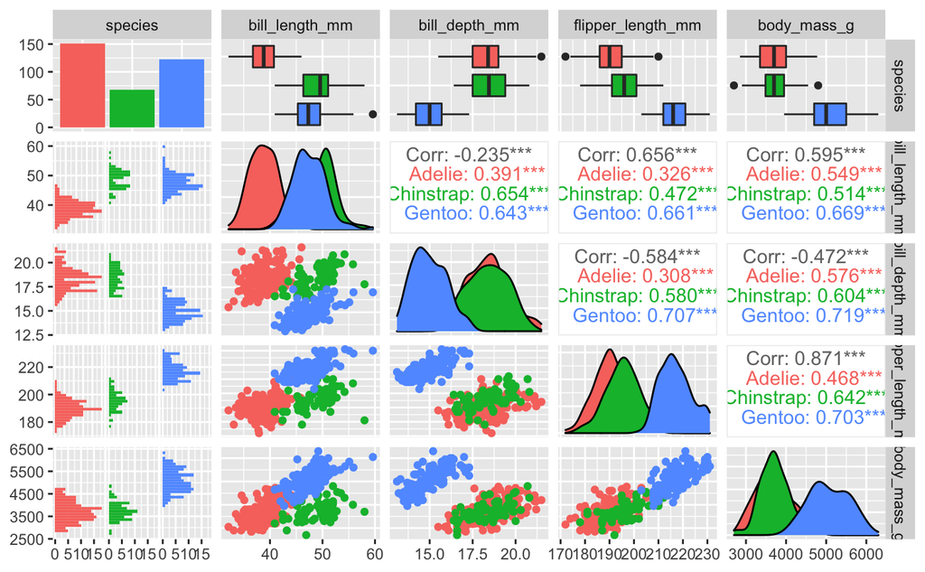

```r
penguins <- read.csv('Downloads/penguins.csv')
library(GGally)
ggpairs(penguins, mapping=ggplot2::aes(colour = species))
```

1. Which species has the most members in the dataset? Adelie
2. Which other variable has the highest correlation with body mass (for the overall dataset)? Flipper length
3. For Adelie, which other variable has the highest correlation with body mass? Bill depth
4. For each field, which species have similar values according to the histogram? Bill length: chinstrap and gentoo Bill depth: chinstrap adn adelie Flipper length: chinstrap and adelie Body mass: chinstrap and adelie
2. Take the function f(x, y, z) = x2 – 3x + y4 – 3y + z2 + 10z + cos(xyz). Find the location of the minimum value. Use c(0, 0 ,0) as the initialization location. Try different initialization locations. Can you find different locations for minima? If you see multiple ones, which one seems to be a global minimum?

```r
fm <- function(x) x[1]^2 - 3*x[1] + x[2]^4 - 3*x[2] + x[3]^2 + 10*x[3] + cos(x[1]*x[2]*x[3])

print(optim(c(0,0,0),fm))
```

```
$par
[1]  0.9586131  0.7348568 -4.8938219

$value
[1] -29.81218

$counts
function gradient
     250       NA

$convergence
[1] 0

$message
NULL
```

so the location of the minimum value is (0.9586131,0.7348568,-4.8938219)

```r
min_vals <- c()
for (i in seq(-10,10,1)){
  for (j in seq(-10,10,1)){
    for (k in seq(-10,10,1)){
      min_vals <- append(min_vals, optim(c(i,j,k),fm)$value)
    }
  }
}
summary(min_vals)
```

```
   Min. 1st Qu.  Median    Mean 3rd Qu.    Max.
 -30.13  -30.13  -29.81  -29.56  -29.81   26.00
```

```r
max_min_val <- min(min_vals)
max_min_val
```

```
[1] -30.12842
```

```r
optim(c(10,10,-10),fm)[1:2]
```

```
$par
[1]  1.801212  1.011950 -5.108920

$value
[1] -30.12827
```

```r
samp <- c(2, 3, 2.5, 3, 1.6, 1.4, 1.3, 1.8, 1.9, 2.4, 4.6)
log_likelyhood <- function(a) length(sample) * log(a) - (a+1) * sum(log(samp))

optimize(log_likelyhood,c(1,100),maximum = TRUE)
```

```
$maximum
[1] 1.000045

$objective
[1] -17.01368
```

so the max : 1.000045

```r
beta_samp <- read.csv('Downloads/beta_samp.csv')
beta_samp
```

| X | x |
| --- | --- |
| 1 | 0.15331557 |
| 2 | 0.45092343 |
| 3 | 0.42762535 |
| 4 | 0.09863622 |
| 5 | 0.57009678 |
| 6 | 0.32115769 |
| 7 | 0.16584069 |
| 8 | 0.53939828 |
| 9 | 0.20442779 |
| 10 | 0.24167126 |

[output cut: 990 more lines]

```r
p_x <- function(para) (-1)*sum(log(dbeta(beta_samp$x, para[1],para[2])))
#?dbeta()
```

2. Use the optim function in R to find the maximum likelihood estimate for the parameters.

```r
optim(c(1,1),p_x)
```

```
$par
[1] 2.97645 4.94619

$value
[1] -4256.899

$counts
function gradient
     277       NA

$convergence
[1] 0

$message
NULL
```

So alpha = 2.97645 and beta = 4.94619

3. Graph the beta distribution for the given parameters between 0 < x < 1.

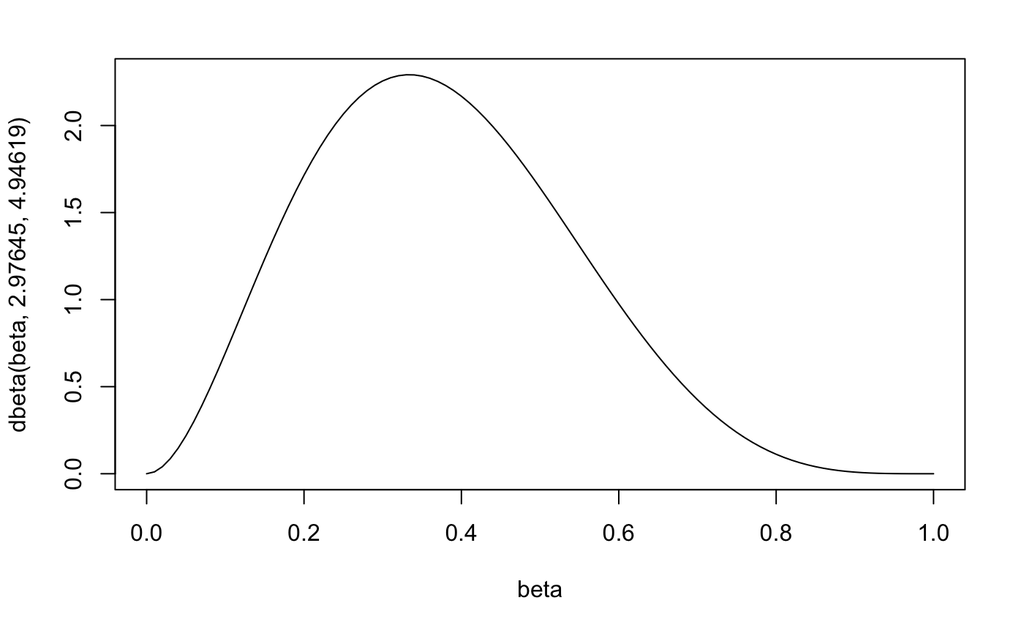

```r
beta = seq(0,1,0.01)
plot(beta, dbeta(beta, 2.97645,4.94619), type = 'l')
```

5. With the penguins dataset, construct a 99% two-sided confidence interval for the mean value for body mass with the t-distribution. Then do the same for each species individually.

```r
penguin_mass <- penguins$body_mass_g
penguin_mean <- mean(penguin_mass)
penguin_sd <- sd(penguin_mass)
penguin_size <- length(penguin_mass)

LCL <- penguin_mean + penguin_sd/sqrt(length(penguin_mass)) * qt(0.005, penguin_size-1)
UCL <- penguin_mean + penguin_sd/sqrt(length(penguin_mass)) * qt(0.995, penguin_size-1)
print(LCL)
```

```
[1] 4089.426
```

```r
print(UCL)
```

```
[1] 4314.083
```

```r
adelie_mass <- penguins[penguins$species=="Adelie",]$body_mass_g
adelie_mean <- mean(adelie_mass)
adelie_sd <- sd(adelie_mass)
adelie_size <- length(adelie_mass)

LCL_adelie <- adelie_mean + adelie_sd/sqrt(length(adelie_mass)) * qt(0.005, adelie_size-1)
UCL_adelie <- adelie_mean + adelie_sd/sqrt(length(adelie_mass)) * qt(0.995, adelie_size-1)
print(LCL_adelie)
```

```
[1] 3603.301
```

```r
print(UCL_adelie)
```

```
[1] 3798.024
```

```r
chinstrap_mass <- penguins[penguins$species=="Chinstrap",]$body_mass_g
chinstrap_mean <- mean(chinstrap_mass)
chinstrap_sd <- sd(chinstrap_mass)
chinstrap_size <- length(chinstrap_mass)

LCL_chinstrap <- chinstrap_mean + chinstrap_sd/sqrt(length(chinstrap_mass)) * qt(0.005, chinstrap_size-1)
UCL_chinstrap <- chinstrap_mean + chinstrap_sd/sqrt(length(chinstrap_mass)) * qt(0.995, chinstrap_size-1)
print(LCL_chinstrap)
```

```
[1] 3609.522
```

```r
print(UCL_chinstrap)
```

```
[1] 3856.655
```

```r
gentoo_mass <- penguins[penguins$species=="Gentoo",]$body_mass_g
gentoo_mean <- mean(gentoo_mass)
gentoo_sd <- sd(gentoo_mass)
gentoo_size <- length(gentoo_mass)

LCL_gentoo <- gentoo_mean + gentoo_sd/sqrt(length(gentoo_mass)) * qt(0.005, gentoo_size-1)
UCL_gentoo <- gentoo_mean + gentoo_sd/sqrt(length(gentoo_mass)) * qt(0.995, gentoo_size-1)
print(LCL_gentoo)
```

```
[1] 4957.074
```

```r
print(UCL_gentoo)
```

```
[1] 5194.959
```